# Risk Factor Analysis

## Outcome Variable

**Outcome Variable:** ever_swasted

## Predictor Variables

**Intervention Variable:** birthlen

**Adjustment Set:**

- arm
- sex
- W_mage
- meducyrs
- feducyrs
- vagbrth
- single
- brthmon
- W_parity
- delta_W_mage
- delta_meducyrs
- delta_feducyrs
- delta_vagbrth
- delta_single
- delta_brthmon
- delta_W_parity

## Stratifying Variables

The analysis was stratified on these variable(s):

- agecat
- studyid
- country

## Data Summary

| agecat | studyid | country | birthlen | ever_swasted | n_cell | n |
| --- | --- | --- | --- | --- | --- | --- |
| 0-24 months (no birth wast) | ki0047075b-MAL-ED | BANGLADESH | >=50 cm | 0 | 26 | 256 |
| 0-24 months (no birth wast) | ki0047075b-MAL-ED | BANGLADESH | >=50 cm | 1 | 3 | 256 |
| 0-24 months (no birth wast) | ki0047075b-MAL-ED | BANGLADESH | <48 cm | 0 | 136 | 256 |
| 0-24 months (no birth wast) | ki0047075b-MAL-ED | BANGLADESH | <48 cm | 1 | 6 | 256 |
| 0-24 months (no birth wast) | ki0047075b-MAL-ED | BANGLADESH | [48-50) cm | 0 | 82 | 256 |
| 0-24 months (no birth wast) | ki0047075b-MAL-ED | BANGLADESH | [48-50) cm | 1 | 3 | 256 |
| 0-24 months (no birth wast) | ki0047075b-MAL-ED | BRAZIL | >=50 cm | 0 | 32 | 191 |
| 0-24 months (no birth wast) | ki0047075b-MAL-ED | BRAZIL | >=50 cm | 1 | 2 | 191 |
| 0-24 months (no birth wast) | ki0047075b-MAL-ED | BRAZIL | <48 cm | 0 | 80 | 191 |
| 0-24 months (no birth wast) | ki0047075b-MAL-ED | BRAZIL | <48 cm | 1 | 0 | 191 |
| 0-24 months (no birth wast) | ki0047075b-MAL-ED | BRAZIL | [48-50) cm | 0 | 76 | 191 |
| 0-24 months (no birth wast) | ki0047075b-MAL-ED | BRAZIL | [48-50) cm | 1 | 1 | 191 |
| 0-24 months (no birth wast) | ki0047075b-MAL-ED | INDIA | >=50 cm | 0 | 24 | 203 |
| 0-24 months (no birth wast) | ki0047075b-MAL-ED | INDIA | >=50 cm | 1 | 1 | 203 |
| 0-24 months (no birth wast) | ki0047075b-MAL-ED | INDIA | <48 cm | 0 | 103 | 203 |
| 0-24 months (no birth wast) | ki0047075b-MAL-ED | INDIA | <48 cm | 1 | 3 | 203 |
| 0-24 months (no birth wast) | ki0047075b-MAL-ED | INDIA | [48-50) cm | 0 | 69 | 203 |
| 0-24 months (no birth wast) | ki0047075b-MAL-ED | INDIA | [48-50) cm | 1 | 3 | 203 |
| 0-24 months (no birth wast) | ki0047075b-MAL-ED | NEPAL | >=50 cm | 0 | 38 | 173 |
| 0-24 months (no birth wast) | ki0047075b-MAL-ED | NEPAL | >=50 cm | 1 | 0 | 173 |
| 0-24 months (no birth wast) | ki0047075b-MAL-ED | NEPAL | <48 cm | 0 | 69 | 173 |
| 0-24 months (no birth wast) | ki0047075b-MAL-ED | NEPAL | <48 cm | 1 | 0 | 173 |
| 0-24 months (no birth wast) | ki0047075b-MAL-ED | NEPAL | [48-50) cm | 0 | 66 | 173 |
| 0-24 months (no birth wast) | ki0047075b-MAL-ED | NEPAL | [48-50) cm | 1 | 0 | 173 |
| 0-24 months (no birth wast) | ki0047075b-MAL-ED | PERU | >=50 cm | 0 | 33 | 288 |
| 0-24 months (no birth wast) | ki0047075b-MAL-ED | PERU | >=50 cm | 1 | 1 | 288 |
| 0-24 months (no birth wast) | ki0047075b-MAL-ED | PERU | <48 cm | 0 | 140 | 288 |
| 0-24 months (no birth wast) | ki0047075b-MAL-ED | PERU | <48 cm | 1 | 2 | 288 |
| 0-24 months (no birth wast) | ki0047075b-MAL-ED | PERU | [48-50) cm | 0 | 112 | 288 |
| 0-24 months (no birth wast) | ki0047075b-MAL-ED | PERU | [48-50) cm | 1 | 0 | 288 |

[output cut: 474 more lines]

The following strata were considered:

- agecat: 0-24 months (no birth wast), studyid: ki0047075b-MAL-ED, country: BANGLADESH
- agecat: 0-24 months (no birth wast), studyid: ki0047075b-MAL-ED, country: BRAZIL
- agecat: 0-24 months (no birth wast), studyid: ki0047075b-MAL-ED, country: INDIA
- agecat: 0-24 months (no birth wast), studyid: ki0047075b-MAL-ED, country: NEPAL
- agecat: 0-24 months (no birth wast), studyid: ki0047075b-MAL-ED, country: PERU
- agecat: 0-24 months (no birth wast), studyid: ki0047075b-MAL-ED, country: SOUTH AFRICA
- agecat: 0-24 months (no birth wast), studyid: ki0047075b-MAL-ED, country: TANZANIA, UNITED REPUBLIC OF
- agecat: 0-24 months (no birth wast), studyid: ki1000108-CMC-V-BCS-2002, country: INDIA
- agecat: 0-24 months (no birth wast), studyid: ki1000108-IRC, country: INDIA
- agecat: 0-24 months (no birth wast), studyid: ki1000109-EE, country: PAKISTAN
- agecat: 0-24 months (no birth wast), studyid: ki1000109-ResPak, country: PAKISTAN
- agecat: 0-24 months (no birth wast), studyid: ki1000304b-SAS-CompFeed, country: INDIA
- agecat: 0-24 months (no birth wast), studyid: ki1017093-NIH-Birth, country: BANGLADESH
- agecat: 0-24 months (no birth wast), studyid: ki1017093b-PROVIDE, country: BANGLADESH
- agecat: 0-24 months (no birth wast), studyid: ki1017093c-NIH-Crypto, country: BANGLADESH
- agecat: 0-24 months (no birth wast), studyid: ki1101329-Keneba, country: GAMBIA
- agecat: 0-24 months (no birth wast), studyid: ki1114097-CMIN, country: BANGLADESH
- agecat: 0-24 months (no birth wast), studyid: ki1114097-CMIN, country: BRAZIL
- agecat: 0-24 months (no birth wast), studyid: ki1114097-CMIN, country: GUINEA-BISSAU
- agecat: 0-24 months (no birth wast), studyid: ki1114097-CMIN, country: PERU
- agecat: 0-24 months (no birth wast), studyid: ki1114097-CONTENT, country: PERU
- agecat: 0-24 months (no birth wast), studyid: ki1119695-PROBIT, country: BELARUS
- agecat: 0-24 months (no birth wast), studyid: ki1126311-ZVITAMBO, country: ZIMBABWE
- agecat: 0-24 months (no birth wast), studyid: ki1135781-COHORTS, country: GUATEMALA
- agecat: 0-24 months (no birth wast), studyid: ki1135781-COHORTS, country: INDIA
- agecat: 0-24 months (no birth wast), studyid: ki1135781-COHORTS, country: PHILIPPINES
- agecat: 0-24 months (no birth wast), studyid: kiGH5241-JiVitA-3, country: BANGLADESH
- agecat: 0-24 months (no birth wast), studyid: kiGH5241-JiVitA-4, country: BANGLADESH
- agecat: 0-6 months (no birth wast), studyid: ki0047075b-MAL-ED, country: BANGLADESH
- agecat: 0-6 months (no birth wast), studyid: ki0047075b-MAL-ED, country: BRAZIL
- agecat: 0-6 months (no birth wast), studyid: ki0047075b-MAL-ED, country: INDIA
- agecat: 0-6 months (no birth wast), studyid: ki0047075b-MAL-ED, country: NEPAL
- agecat: 0-6 months (no birth wast), studyid: ki0047075b-MAL-ED, country: PERU
- agecat: 0-6 months (no birth wast), studyid: ki0047075b-MAL-ED, country: SOUTH AFRICA
- agecat: 0-6 months (no birth wast), studyid: ki0047075b-MAL-ED, country: TANZANIA, UNITED REPUBLIC OF
- agecat: 0-6 months (no birth wast), studyid: ki1000108-CMC-V-BCS-2002, country: INDIA
- agecat: 0-6 months (no birth wast), studyid: ki1000108-IRC, country: INDIA
- agecat: 0-6 months (no birth wast), studyid: ki1000109-EE, country: PAKISTAN
- agecat: 0-6 months (no birth wast), studyid: ki1000109-ResPak, country: PAKISTAN
- agecat: 0-6 months (no birth wast), studyid: ki1000304b-SAS-CompFeed, country: INDIA
- agecat: 0-6 months (no birth wast), studyid: ki1017093-NIH-Birth, country: BANGLADESH
- agecat: 0-6 months (no birth wast), studyid: ki1017093b-PROVIDE, country: BANGLADESH
- agecat: 0-6 months (no birth wast), studyid: ki1017093c-NIH-Crypto, country: BANGLADESH
- agecat: 0-6 months (no birth wast), studyid: ki1101329-Keneba, country: GAMBIA
- agecat: 0-6 months (no birth wast), studyid: ki1114097-CMIN, country: BANGLADESH
- agecat: 0-6 months (no birth wast), studyid: ki1114097-CMIN, country: BRAZIL
- agecat: 0-6 months (no birth wast), studyid: ki1114097-CMIN, country: GUINEA-BISSAU
- agecat: 0-6 months (no birth wast), studyid: ki1114097-CMIN, country: PERU
- agecat: 0-6 months (no birth wast), studyid: ki1114097-CONTENT, country: PERU
- agecat: 0-6 months (no birth wast), studyid: ki1119695-PROBIT, country: BELARUS
- agecat: 0-6 months (no birth wast), studyid: ki1126311-ZVITAMBO, country: ZIMBABWE
- agecat: 0-6 months (no birth wast), studyid: ki1135781-COHORTS, country: GUATEMALA
- agecat: 0-6 months (no birth wast), studyid: ki1135781-COHORTS, country: INDIA
- agecat: 0-6 months (no birth wast), studyid: ki1135781-COHORTS, country: PHILIPPINES
- agecat: 0-6 months (no birth wast), studyid: kiGH5241-JiVitA-3, country: BANGLADESH
- agecat: 0-6 months (no birth wast), studyid: kiGH5241-JiVitA-4, country: BANGLADESH
- agecat: 6-24 months, studyid: ki0047075b-MAL-ED, country: BANGLADESH
- agecat: 6-24 months, studyid: ki0047075b-MAL-ED, country: BRAZIL
- agecat: 6-24 months, studyid: ki0047075b-MAL-ED, country: INDIA
- agecat: 6-24 months, studyid: ki0047075b-MAL-ED, country: NEPAL
- agecat: 6-24 months, studyid: ki0047075b-MAL-ED, country: PERU
- agecat: 6-24 months, studyid: ki0047075b-MAL-ED, country: SOUTH AFRICA
- agecat: 6-24 months, studyid: ki0047075b-MAL-ED, country: TANZANIA, UNITED REPUBLIC OF
- agecat: 6-24 months, studyid: ki1000108-CMC-V-BCS-2002, country: INDIA
- agecat: 6-24 months, studyid: ki1000108-IRC, country: INDIA
- agecat: 6-24 months, studyid: ki1000109-EE, country: PAKISTAN
- agecat: 6-24 months, studyid: ki1000109-ResPak, country: PAKISTAN
- agecat: 6-24 months, studyid: ki1000304b-SAS-CompFeed, country: INDIA
- agecat: 6-24 months, studyid: ki1017093-NIH-Birth, country: BANGLADESH
- agecat: 6-24 months, studyid: ki1017093b-PROVIDE, country: BANGLADESH
- agecat: 6-24 months, studyid: ki1017093c-NIH-Crypto, country: BANGLADESH
- agecat: 6-24 months, studyid: ki1101329-Keneba, country: GAMBIA
- agecat: 6-24 months, studyid: ki1114097-CMIN, country: BANGLADESH
- agecat: 6-24 months, studyid: ki1114097-CMIN, country: BRAZIL
- agecat: 6-24 months, studyid: ki1114097-CMIN, country: GUINEA-BISSAU
- agecat: 6-24 months, studyid: ki1114097-CMIN, country: PERU
- agecat: 6-24 months, studyid: ki1114097-CONTENT, country: PERU
- agecat: 6-24 months, studyid: ki1119695-PROBIT, country: BELARUS
- agecat: 6-24 months, studyid: ki1126311-ZVITAMBO, country: ZIMBABWE
- agecat: 6-24 months, studyid: ki1135781-COHORTS, country: GUATEMALA
- agecat: 6-24 months, studyid: ki1135781-COHORTS, country: INDIA
- agecat: 6-24 months, studyid: ki1135781-COHORTS, country: PHILIPPINES
- agecat: 6-24 months, studyid: kiGH5241-JiVitA-3, country: BANGLADESH
- agecat: 6-24 months, studyid: kiGH5241-JiVitA-4, country: BANGLADESH

### Dropped Strata

Some strata were dropped due to rare outcomes:

- agecat: 0-24 months (no birth wast), studyid: ki0047075b-MAL-ED, country: BANGLADESH
- agecat: 0-24 months (no birth wast), studyid: ki0047075b-MAL-ED, country: BRAZIL
- agecat: 0-24 months (no birth wast), studyid: ki0047075b-MAL-ED, country: INDIA
- agecat: 0-24 months (no birth wast), studyid: ki0047075b-MAL-ED, country: NEPAL
- agecat: 0-24 months (no birth wast), studyid: ki0047075b-MAL-ED, country: PERU
- agecat: 0-24 months (no birth wast), studyid: ki0047075b-MAL-ED, country: SOUTH AFRICA
- agecat: 0-24 months (no birth wast), studyid: ki0047075b-MAL-ED, country: TANZANIA, UNITED REPUBLIC OF
- agecat: 0-24 months (no birth wast), studyid: ki1000108-CMC-V-BCS-2002, country: INDIA
- agecat: 0-24 months (no birth wast), studyid: ki1000109-EE, country: PAKISTAN
- agecat: 0-24 months (no birth wast), studyid: ki1000109-ResPak, country: PAKISTAN
- agecat: 0-24 months (no birth wast), studyid: ki1017093-NIH-Birth, country: BANGLADESH
- agecat: 0-24 months (no birth wast), studyid: ki1017093b-PROVIDE, country: BANGLADESH
- agecat: 0-24 months (no birth wast), studyid: ki1017093c-NIH-Crypto, country: BANGLADESH
- agecat: 0-24 months (no birth wast), studyid: ki1114097-CMIN, country: BANGLADESH
- agecat: 0-24 months (no birth wast), studyid: ki1114097-CMIN, country: BRAZIL
- agecat: 0-24 months (no birth wast), studyid: ki1114097-CMIN, country: GUINEA-BISSAU
- agecat: 0-24 months (no birth wast), studyid: ki1114097-CMIN, country: PERU
- agecat: 0-24 months (no birth wast), studyid: ki1114097-CONTENT, country: PERU
- agecat: 0-24 months (no birth wast), studyid: ki1119695-PROBIT, country: BELARUS
- agecat: 0-24 months (no birth wast), studyid: ki1135781-COHORTS, country: GUATEMALA
- agecat: 0-6 months (no birth wast), studyid: ki0047075b-MAL-ED, country: BANGLADESH
- agecat: 0-6 months (no birth wast), studyid: ki0047075b-MAL-ED, country: BRAZIL
- agecat: 0-6 months (no birth wast), studyid: ki0047075b-MAL-ED, country: INDIA
- agecat: 0-6 months (no birth wast), studyid: ki0047075b-MAL-ED, country: NEPAL
- agecat: 0-6 months (no birth wast), studyid: ki0047075b-MAL-ED, country: PERU
- agecat: 0-6 months (no birth wast), studyid: ki0047075b-MAL-ED, country: SOUTH AFRICA
- agecat: 0-6 months (no birth wast), studyid: ki0047075b-MAL-ED, country: TANZANIA, UNITED REPUBLIC OF
- agecat: 0-6 months (no birth wast), studyid: ki1000108-CMC-V-BCS-2002, country: INDIA
- agecat: 0-6 months (no birth wast), studyid: ki1000109-EE, country: PAKISTAN
- agecat: 0-6 months (no birth wast), studyid: ki1000109-ResPak, country: PAKISTAN
- agecat: 0-6 months (no birth wast), studyid: ki1000304b-SAS-CompFeed, country: INDIA
- agecat: 0-6 months (no birth wast), studyid: ki1017093-NIH-Birth, country: BANGLADESH
- agecat: 0-6 months (no birth wast), studyid: ki1017093b-PROVIDE, country: BANGLADESH
- agecat: 0-6 months (no birth wast), studyid: ki1017093c-NIH-Crypto, country: BANGLADESH
- agecat: 0-6 months (no birth wast), studyid: ki1114097-CMIN, country: BANGLADESH
- agecat: 0-6 months (no birth wast), studyid: ki1114097-CMIN, country: BRAZIL
- agecat: 0-6 months (no birth wast), studyid: ki1114097-CMIN, country: GUINEA-BISSAU
- agecat: 0-6 months (no birth wast), studyid: ki1114097-CMIN, country: PERU
- agecat: 0-6 months (no birth wast), studyid: ki1114097-CONTENT, country: PERU
- agecat: 0-6 months (no birth wast), studyid: ki1119695-PROBIT, country: BELARUS
- agecat: 0-6 months (no birth wast), studyid: ki1135781-COHORTS, country: GUATEMALA
- agecat: 0-6 months (no birth wast), studyid: kiGH5241-JiVitA-4, country: BANGLADESH
- agecat: 6-24 months, studyid: ki0047075b-MAL-ED, country: BANGLADESH
- agecat: 6-24 months, studyid: ki0047075b-MAL-ED, country: BRAZIL
- agecat: 6-24 months, studyid: ki0047075b-MAL-ED, country: INDIA
- agecat: 6-24 months, studyid: ki0047075b-MAL-ED, country: NEPAL
- agecat: 6-24 months, studyid: ki0047075b-MAL-ED, country: PERU
- agecat: 6-24 months, studyid: ki0047075b-MAL-ED, country: SOUTH AFRICA
- agecat: 6-24 months, studyid: ki0047075b-MAL-ED, country: TANZANIA, UNITED REPUBLIC OF
- agecat: 6-24 months, studyid: ki1000108-CMC-V-BCS-2002, country: INDIA
- agecat: 6-24 months, studyid: ki1000109-EE, country: PAKISTAN
- agecat: 6-24 months, studyid: ki1000109-ResPak, country: PAKISTAN
- agecat: 6-24 months, studyid: ki1017093-NIH-Birth, country: BANGLADESH
- agecat: 6-24 months, studyid: ki1017093b-PROVIDE, country: BANGLADESH
- agecat: 6-24 months, studyid: ki1017093c-NIH-Crypto, country: BANGLADESH
- agecat: 6-24 months, studyid: ki1114097-CMIN, country: BANGLADESH
- agecat: 6-24 months, studyid: ki1114097-CMIN, country: BRAZIL
- agecat: 6-24 months, studyid: ki1114097-CMIN, country: GUINEA-BISSAU
- agecat: 6-24 months, studyid: ki1114097-CMIN, country: PERU
- agecat: 6-24 months, studyid: ki1114097-CONTENT, country: PERU
- agecat: 6-24 months, studyid: ki1119695-PROBIT, country: BELARUS
- agecat: 6-24 months, studyid: ki1135781-COHORTS, country: GUATEMALA

## Methods Detail

We’re interested in the causal parameters $E[Y_a]$ for all values of $a \in \mathcal{A}$. These parameters represent the mean outcome if, possibly contrary to fact, we intervened to set all units to have $A=a$. Under the randomization and positivity assumptions, these are identified by the statistical parameters $\psi_a=E_W[E_{Y|A,W}(Y|A=a,W)]$. In addition, we’re interested in the mean of $Y$, $E[Y]$ under no intervention (the observed mean). We will estimate these parameters by using SuperLearner to fit the relevant likelihood factors – $E_{Y|A,W}(Y|A=a,W)$ and $p(A=a|W)$, and then updating our likelihood fit using a joint TMLE.

For unadjusted analyses ($W=\{\}$), initial likelihoods were estimated using Lrnr_glm to estimate the simple $E(Y|A)$ and Lrnr_mean to estimate $p(A)$. For adjusted analyses, a small library containing Lrnr_glmnet, Lrnr_xgboost, and Lrnr_mean was used.

Having estimated these parameters, we will then use the delta method to estimate relative risks and attributable risks relative to a prespecified baseline level of $A$.

# Results Detail

## Results Plots

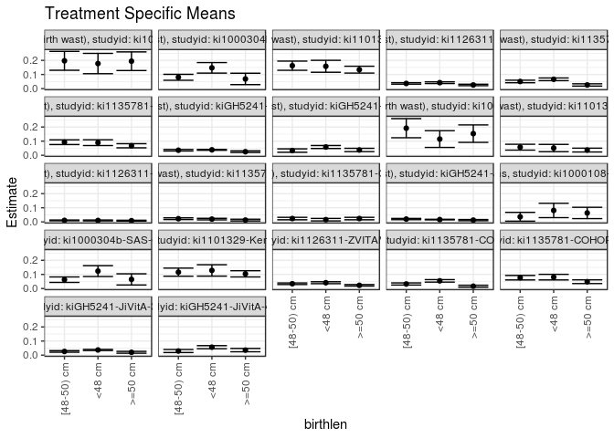

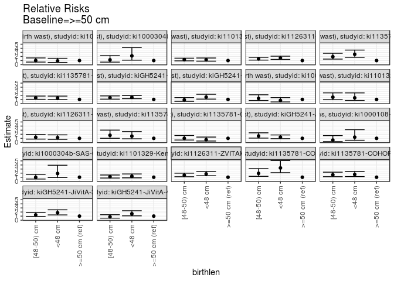

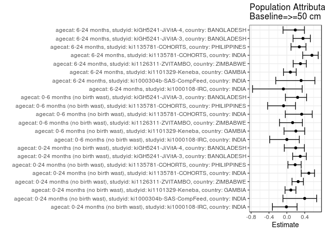

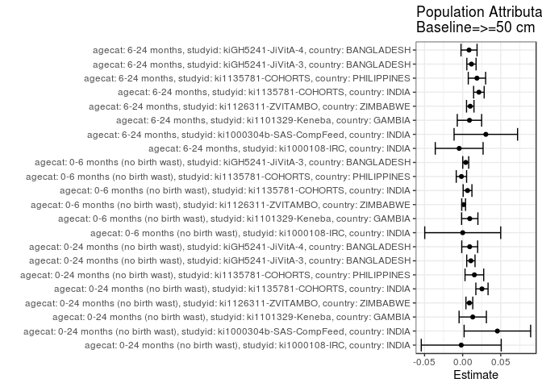

## Results Table

### Parameter: TSM

| agecat | studyid | country | intervention_level | baseline_level | estimate | ci_lower | ci_upper |
| --- | --- | --- | --- | --- | --- | --- | --- |
| 0-24 months (no birth wast) | ki1000108-IRC | INDIA | >=50 cm | NA | 0.1941478 | 0.1281082 | 0.2601874 |
| 0-24 months (no birth wast) | ki1000108-IRC | INDIA | <48 cm | NA | 0.1775993 | 0.1056017 | 0.2495968 |
| 0-24 months (no birth wast) | ki1000108-IRC | INDIA | [48-50) cm | NA | 0.1969241 | 0.1300465 | 0.2638017 |
| 0-24 months (no birth wast) | ki1000304b-SAS-CompFeed | INDIA | >=50 cm | NA | 0.0685928 | 0.0283638 | 0.1088219 |
| 0-24 months (no birth wast) | ki1000304b-SAS-CompFeed | INDIA | <48 cm | NA | 0.1471442 | 0.1097575 | 0.1845309 |
| 0-24 months (no birth wast) | ki1000304b-SAS-CompFeed | INDIA | [48-50) cm | NA | 0.0802033 | 0.0592320 | 0.1011746 |
| 0-24 months (no birth wast) | ki1101329-Keneba | GAMBIA | >=50 cm | NA | 0.1342424 | 0.1098917 | 0.1585932 |
| 0-24 months (no birth wast) | ki1101329-Keneba | GAMBIA | <48 cm | NA | 0.1580984 | 0.1157649 | 0.2004318 |
| 0-24 months (no birth wast) | ki1101329-Keneba | GAMBIA | [48-50) cm | NA | 0.1623763 | 0.1297690 | 0.1949836 |
| 0-24 months (no birth wast) | ki1126311-ZVITAMBO | ZIMBABWE | >=50 cm | NA | 0.0258344 | 0.0208534 | 0.0308154 |
| 0-24 months (no birth wast) | ki1126311-ZVITAMBO | ZIMBABWE | <48 cm | NA | 0.0420667 | 0.0359320 | 0.0482013 |
| 0-24 months (no birth wast) | ki1126311-ZVITAMBO | ZIMBABWE | [48-50) cm | NA | 0.0365481 | 0.0314000 | 0.0416962 |
| 0-24 months (no birth wast) | ki1135781-COHORTS | INDIA | >=50 cm | NA | 0.0260716 | 0.0179696 | 0.0341735 |
| 0-24 months (no birth wast) | ki1135781-COHORTS | INDIA | <48 cm | NA | 0.0660046 | 0.0564479 | 0.0755612 |
| 0-24 months (no birth wast) | ki1135781-COHORTS | INDIA | [48-50) cm | NA | 0.0505918 | 0.0415100 | 0.0596736 |
| 0-24 months (no birth wast) | ki1135781-COHORTS | PHILIPPINES | >=50 cm | NA | 0.0673201 | 0.0526444 | 0.0819958 |
| 0-24 months (no birth wast) | ki1135781-COHORTS | PHILIPPINES | <48 cm | NA | 0.0892170 | 0.0688024 | 0.1096316 |
| 0-24 months (no birth wast) | ki1135781-COHORTS | PHILIPPINES | [48-50) cm | NA | 0.0926481 | 0.0758665 | 0.1094298 |
| 0-24 months (no birth wast) | kiGH5241-JiVitA-3 | BANGLADESH | >=50 cm | NA | 0.0251833 | 0.0193179 | 0.0310486 |
| 0-24 months (no birth wast) | kiGH5241-JiVitA-3 | BANGLADESH | <48 cm | NA | 0.0384854 | 0.0352288 | 0.0417421 |
| 0-24 months (no birth wast) | kiGH5241-JiVitA-3 | BANGLADESH | [48-50) cm | NA | 0.0356807 | 0.0300945 | 0.0412670 |
| 0-24 months (no birth wast) | kiGH5241-JiVitA-4 | BANGLADESH | >=50 cm | NA | 0.0373465 | 0.0255692 | 0.0491238 |
| 0-24 months (no birth wast) | kiGH5241-JiVitA-4 | BANGLADESH | <48 cm | NA | 0.0585277 | 0.0479738 | 0.0690815 |
| 0-24 months (no birth wast) | kiGH5241-JiVitA-4 | BANGLADESH | [48-50) cm | NA | 0.0332667 | 0.0211773 | 0.0453562 |
| 0-6 months (no birth wast) | ki1000108-IRC | INDIA | >=50 cm | NA | 0.1531383 | 0.0912787 | 0.2149979 |
| 0-6 months (no birth wast) | ki1000108-IRC | INDIA | <48 cm | NA | 0.1147279 | 0.0554207 | 0.1740352 |
| 0-6 months (no birth wast) | ki1000108-IRC | INDIA | [48-50) cm | NA | 0.1916790 | 0.1238491 | 0.2595089 |
| 0-6 months (no birth wast) | ki1101329-Keneba | GAMBIA | >=50 cm | NA | 0.0367640 | 0.0231283 | 0.0503998 |
| 0-6 months (no birth wast) | ki1101329-Keneba | GAMBIA | <48 cm | NA | 0.0512336 | 0.0253879 | 0.0770793 |
| 0-6 months (no birth wast) | ki1101329-Keneba | GAMBIA | [48-50) cm | NA | 0.0572341 | 0.0365400 | 0.0779281 |
| 0-6 months (no birth wast) | ki1126311-ZVITAMBO | ZIMBABWE | >=50 cm | NA | 0.0086173 | 0.0057111 | 0.0115235 |
| 0-6 months (no birth wast) | ki1126311-ZVITAMBO | ZIMBABWE | <48 cm | NA | 0.0101250 | 0.0071023 | 0.0131477 |
| 0-6 months (no birth wast) | ki1126311-ZVITAMBO | ZIMBABWE | [48-50) cm | NA | 0.0107522 | 0.0079441 | 0.0135603 |
| 0-6 months (no birth wast) | ki1135781-COHORTS | INDIA | >=50 cm | NA | 0.0129172 | 0.0068015 | 0.0190329 |
| 0-6 months (no birth wast) | ki1135781-COHORTS | INDIA | <48 cm | NA | 0.0197451 | 0.0142870 | 0.0252032 |
| 0-6 months (no birth wast) | ki1135781-COHORTS | INDIA | [48-50) cm | NA | 0.0225809 | 0.0164307 | 0.0287312 |
| 0-6 months (no birth wast) | ki1135781-COHORTS | PHILIPPINES | >=50 cm | NA | 0.0236972 | 0.0148691 | 0.0325253 |
| 0-6 months (no birth wast) | ki1135781-COHORTS | PHILIPPINES | <48 cm | NA | 0.0157606 | 0.0068569 | 0.0246643 |
| 0-6 months (no birth wast) | ki1135781-COHORTS | PHILIPPINES | [48-50) cm | NA | 0.0236225 | 0.0148717 | 0.0323734 |
| 0-6 months (no birth wast) | kiGH5241-JiVitA-3 | BANGLADESH | >=50 cm | NA | 0.0126954 | 0.0085140 | 0.0168767 |
| 0-6 months (no birth wast) | kiGH5241-JiVitA-3 | BANGLADESH | <48 cm | NA | 0.0163302 | 0.0141609 | 0.0184994 |
| 0-6 months (no birth wast) | kiGH5241-JiVitA-3 | BANGLADESH | [48-50) cm | NA | 0.0199867 | 0.0155486 | 0.0244248 |
| 6-24 months | ki1000108-IRC | INDIA | >=50 cm | NA | 0.0633803 | 0.0232549 | 0.1035056 |
| 6-24 months | ki1000108-IRC | INDIA | <48 cm | NA | 0.0810811 | 0.0302369 | 0.1319252 |
| 6-24 months | ki1000108-IRC | INDIA | [48-50) cm | NA | 0.0362319 | 0.0050145 | 0.0674493 |
| 6-24 months | ki1000304b-SAS-CompFeed | INDIA | >=50 cm | NA | 0.0647868 | 0.0251855 | 0.1043881 |
| 6-24 months | ki1000304b-SAS-CompFeed | INDIA | <48 cm | NA | 0.1235847 | 0.0850552 | 0.1621142 |
| 6-24 months | ki1000304b-SAS-CompFeed | INDIA | [48-50) cm | NA | 0.0627962 | 0.0433150 | 0.0822775 |
| 6-24 months | ki1101329-Keneba | GAMBIA | >=50 cm | NA | 0.1040523 | 0.0820663 | 0.1260382 |
| 6-24 months | ki1101329-Keneba | GAMBIA | <48 cm | NA | 0.1282712 | 0.0880061 | 0.1685364 |
| 6-24 months | ki1101329-Keneba | GAMBIA | [48-50) cm | NA | 0.1159501 | 0.0873072 | 0.1445930 |
| 6-24 months | ki1126311-ZVITAMBO | ZIMBABWE | >=50 cm | NA | 0.0227586 | 0.0174077 | 0.0281094 |
| 6-24 months | ki1126311-ZVITAMBO | ZIMBABWE | <48 cm | NA | 0.0410744 | 0.0342595 | 0.0478893 |
| 6-24 months | ki1126311-ZVITAMBO | ZIMBABWE | [48-50) cm | NA | 0.0339824 | 0.0284050 | 0.0395598 |
| 6-24 months | ki1135781-COHORTS | INDIA | >=50 cm | NA | 0.0166160 | 0.0098573 | 0.0233747 |
| 6-24 months | ki1135781-COHORTS | INDIA | <48 cm | NA | 0.0544114 | 0.0455904 | 0.0632323 |
| 6-24 months | ki1135781-COHORTS | INDIA | [48-50) cm | NA | 0.0323134 | 0.0248309 | 0.0397959 |
| 6-24 months | ki1135781-COHORTS | PHILIPPINES | >=50 cm | NA | 0.0483368 | 0.0352213 | 0.0614523 |
| 6-24 months | ki1135781-COHORTS | PHILIPPINES | <48 cm | NA | 0.0807673 | 0.0607503 | 0.1007842 |
| 6-24 months | ki1135781-COHORTS | PHILIPPINES | [48-50) cm | NA | 0.0767333 | 0.0607609 | 0.0927057 |
| 6-24 months | kiGH5241-JiVitA-3 | BANGLADESH | >=50 cm | NA | 0.0203930 | 0.0138088 | 0.0269772 |
| 6-24 months | kiGH5241-JiVitA-3 | BANGLADESH | <48 cm | NA | 0.0370130 | 0.0330670 | 0.0409590 |
| 6-24 months | kiGH5241-JiVitA-3 | BANGLADESH | [48-50) cm | NA | 0.0263518 | 0.0205996 | 0.0321041 |
| 6-24 months | kiGH5241-JiVitA-4 | BANGLADESH | >=50 cm | NA | 0.0358870 | 0.0241224 | 0.0476517 |
| 6-24 months | kiGH5241-JiVitA-4 | BANGLADESH | <48 cm | NA | 0.0565185 | 0.0455868 | 0.0674502 |
| 6-24 months | kiGH5241-JiVitA-4 | BANGLADESH | [48-50) cm | NA | 0.0294717 | 0.0187694 | 0.0401739 |

### Parameter: E(Y)

| agecat | studyid | country | intervention_level | baseline_level | estimate | ci_lower | ci_upper |
| --- | --- | --- | --- | --- | --- | --- | --- |
| 0-24 months (no birth wast) | ki1000108-IRC | INDIA | NA | NA | 0.1923077 | 0.1531430 | 0.2314724 |
| 0-24 months (no birth wast) | ki1000304b-SAS-CompFeed | INDIA | NA | NA | 0.1141706 | 0.0903032 | 0.1380379 |
| 0-24 months (no birth wast) | ki1101329-Keneba | GAMBIA | NA | NA | 0.1474774 | 0.1297967 | 0.1651581 |
| 0-24 months (no birth wast) | ki1126311-ZVITAMBO | ZIMBABWE | NA | NA | 0.0346234 | 0.0315379 | 0.0377089 |
| 0-24 months (no birth wast) | ki1135781-COHORTS | INDIA | NA | NA | 0.0514063 | 0.0459957 | 0.0568168 |
| 0-24 months (no birth wast) | ki1135781-COHORTS | PHILIPPINES | NA | NA | 0.0826968 | 0.0728574 | 0.0925361 |
| 0-24 months (no birth wast) | kiGH5241-JiVitA-3 | BANGLADESH | NA | NA | 0.0359842 | 0.0333710 | 0.0385974 |
| 0-24 months (no birth wast) | kiGH5241-JiVitA-4 | BANGLADESH | NA | NA | 0.0465950 | 0.0398949 | 0.0532951 |
| 0-6 months (no birth wast) | ki1000108-IRC | INDIA | NA | NA | 0.1532258 | 0.1165727 | 0.1898789 |
| 0-6 months (no birth wast) | ki1101329-Keneba | GAMBIA | NA | NA | 0.0460829 | 0.0355357 | 0.0566302 |
| 0-6 months (no birth wast) | ki1126311-ZVITAMBO | ZIMBABWE | NA | NA | 0.0098928 | 0.0082070 | 0.0115785 |
| 0-6 months (no birth wast) | ki1135781-COHORTS | INDIA | NA | NA | 0.0193325 | 0.0158632 | 0.0228017 |
| 0-6 months (no birth wast) | ki1135781-COHORTS | PHILIPPINES | NA | NA | 0.0220736 | 0.0168064 | 0.0273407 |
| 0-6 months (no birth wast) | kiGH5241-JiVitA-3 | BANGLADESH | NA | NA | 0.0167254 | 0.0148982 | 0.0185526 |
| 6-24 months | ki1000108-IRC | INDIA | NA | NA | 0.0588235 | 0.0354714 | 0.0821757 |
| 6-24 months | ki1000304b-SAS-CompFeed | INDIA | NA | NA | 0.0952035 | 0.0698704 | 0.1205365 |
| 6-24 months | ki1101329-Keneba | GAMBIA | NA | NA | 0.1129792 | 0.0968836 | 0.1290747 |
| 6-24 months | ki1126311-ZVITAMBO | ZIMBABWE | NA | NA | 0.0327342 | 0.0293418 | 0.0361265 |
| 6-24 months | ki1135781-COHORTS | INDIA | NA | NA | 0.0379316 | 0.0331642 | 0.0426990 |
| 6-24 months | ki1135781-COHORTS | PHILIPPINES | NA | NA | 0.0670949 | 0.0578297 | 0.0763601 |
| 6-24 months | kiGH5241-JiVitA-3 | BANGLADESH | NA | NA | 0.0319406 | 0.0290104 | 0.0348708 |
| 6-24 months | kiGH5241-JiVitA-4 | BANGLADESH | NA | NA | 0.0442557 | 0.0375111 | 0.0510003 |

### Parameter: RR

| agecat | studyid | country | intervention_level | baseline_level | estimate | ci_lower | ci_upper |
| --- | --- | --- | --- | --- | --- | --- | --- |
| 0-24 months (no birth wast) | ki1000108-IRC | INDIA | >=50 cm | >=50 cm | 1.0000000 | 1.0000000 | 1.000000 |
| 0-24 months (no birth wast) | ki1000108-IRC | INDIA | <48 cm | >=50 cm | 0.9147632 | 0.5387988 | 1.553069 |
| 0-24 months (no birth wast) | ki1000108-IRC | INDIA | [48-50) cm | >=50 cm | 1.0142998 | 0.6267276 | 1.641549 |
| 0-24 months (no birth wast) | ki1000304b-SAS-CompFeed | INDIA | >=50 cm | >=50 cm | 1.0000000 | 1.0000000 | 1.000000 |
| 0-24 months (no birth wast) | ki1000304b-SAS-CompFeed | INDIA | <48 cm | >=50 cm | 2.1451830 | 1.0986057 | 4.188773 |
| 0-24 months (no birth wast) | ki1000304b-SAS-CompFeed | INDIA | [48-50) cm | >=50 cm | 1.1692657 | 0.6196455 | 2.206394 |
| 0-24 months (no birth wast) | ki1101329-Keneba | GAMBIA | >=50 cm | >=50 cm | 1.0000000 | 1.0000000 | 1.000000 |
| 0-24 months (no birth wast) | ki1101329-Keneba | GAMBIA | <48 cm | >=50 cm | 1.1777076 | 0.8526702 | 1.626649 |
| 0-24 months (no birth wast) | ki1101329-Keneba | GAMBIA | [48-50) cm | >=50 cm | 1.2095750 | 0.9232112 | 1.584764 |
| 0-24 months (no birth wast) | ki1126311-ZVITAMBO | ZIMBABWE | >=50 cm | >=50 cm | 1.0000000 | 1.0000000 | 1.000000 |
| 0-24 months (no birth wast) | ki1126311-ZVITAMBO | ZIMBABWE | <48 cm | >=50 cm | 1.6283199 | 1.2786371 | 2.073634 |
| 0-24 months (no birth wast) | ki1126311-ZVITAMBO | ZIMBABWE | [48-50) cm | >=50 cm | 1.4147062 | 1.1142160 | 1.796235 |
| 0-24 months (no birth wast) | ki1135781-COHORTS | INDIA | >=50 cm | >=50 cm | 1.0000000 | 1.0000000 | 1.000000 |
| 0-24 months (no birth wast) | ki1135781-COHORTS | INDIA | <48 cm | >=50 cm | 2.5316670 | 1.7971114 | 3.566467 |
| 0-24 months (no birth wast) | ki1135781-COHORTS | INDIA | [48-50) cm | >=50 cm | 1.9404951 | 1.3555535 | 2.777848 |
| 0-24 months (no birth wast) | ki1135781-COHORTS | PHILIPPINES | >=50 cm | >=50 cm | 1.0000000 | 1.0000000 | 1.000000 |
| 0-24 months (no birth wast) | ki1135781-COHORTS | PHILIPPINES | <48 cm | >=50 cm | 1.3252648 | 0.9663339 | 1.817516 |
| 0-24 months (no birth wast) | ki1135781-COHORTS | PHILIPPINES | [48-50) cm | >=50 cm | 1.3762321 | 1.0369195 | 1.826579 |
| 0-24 months (no birth wast) | kiGH5241-JiVitA-3 | BANGLADESH | >=50 cm | >=50 cm | 1.0000000 | 1.0000000 | 1.000000 |
| 0-24 months (no birth wast) | kiGH5241-JiVitA-3 | BANGLADESH | <48 cm | >=50 cm | 1.5282148 | 1.1961099 | 1.952530 |
| 0-24 months (no birth wast) | kiGH5241-JiVitA-3 | BANGLADESH | [48-50) cm | >=50 cm | 1.4168426 | 1.0772961 | 1.863409 |
| 0-24 months (no birth wast) | kiGH5241-JiVitA-4 | BANGLADESH | >=50 cm | >=50 cm | 1.0000000 | 1.0000000 | 1.000000 |
| 0-24 months (no birth wast) | kiGH5241-JiVitA-4 | BANGLADESH | <48 cm | >=50 cm | 1.5671513 | 1.0841637 | 2.265307 |
| 0-24 months (no birth wast) | kiGH5241-JiVitA-4 | BANGLADESH | [48-50) cm | >=50 cm | 0.8907577 | 0.5501118 | 1.442342 |
| 0-6 months (no birth wast) | ki1000108-IRC | INDIA | >=50 cm | >=50 cm | 1.0000000 | 1.0000000 | 1.000000 |
| 0-6 months (no birth wast) | ki1000108-IRC | INDIA | <48 cm | >=50 cm | 0.7491786 | 0.3889811 | 1.442920 |
| 0-6 months (no birth wast) | ki1000108-IRC | INDIA | [48-50) cm | >=50 cm | 1.2516722 | 0.7310456 | 2.143072 |
| 0-6 months (no birth wast) | ki1101329-Keneba | GAMBIA | >=50 cm | >=50 cm | 1.0000000 | 1.0000000 | 1.000000 |
| 0-6 months (no birth wast) | ki1101329-Keneba | GAMBIA | <48 cm | >=50 cm | 1.3935799 | 0.7456494 | 2.604528 |
| 0-6 months (no birth wast) | ki1101329-Keneba | GAMBIA | [48-50) cm | >=50 cm | 1.5567944 | 0.9278312 | 2.612123 |
| 0-6 months (no birth wast) | ki1126311-ZVITAMBO | ZIMBABWE | >=50 cm | >=50 cm | 1.0000000 | 1.0000000 | 1.000000 |
| 0-6 months (no birth wast) | ki1126311-ZVITAMBO | ZIMBABWE | <48 cm | >=50 cm | 1.1749661 | 0.7488814 | 1.843477 |
| 0-6 months (no birth wast) | ki1126311-ZVITAMBO | ZIMBABWE | [48-50) cm | >=50 cm | 1.2477430 | 0.8145492 | 1.911318 |
| 0-6 months (no birth wast) | ki1135781-COHORTS | INDIA | >=50 cm | >=50 cm | 1.0000000 | 1.0000000 | 1.000000 |
| 0-6 months (no birth wast) | ki1135781-COHORTS | INDIA | <48 cm | >=50 cm | 1.5285910 | 0.8835560 | 2.644530 |
| 0-6 months (no birth wast) | ki1135781-COHORTS | INDIA | [48-50) cm | >=50 cm | 1.7481316 | 1.0124804 | 3.018295 |
| 0-6 months (no birth wast) | ki1135781-COHORTS | PHILIPPINES | >=50 cm | >=50 cm | 1.0000000 | 1.0000000 | 1.000000 |
| 0-6 months (no birth wast) | ki1135781-COHORTS | PHILIPPINES | <48 cm | >=50 cm | 0.6650831 | 0.3379905 | 1.308722 |
| 0-6 months (no birth wast) | ki1135781-COHORTS | PHILIPPINES | [48-50) cm | >=50 cm | 0.9968481 | 0.5894184 | 1.685910 |
| 0-6 months (no birth wast) | kiGH5241-JiVitA-3 | BANGLADESH | >=50 cm | >=50 cm | 1.0000000 | 1.0000000 | 1.000000 |
| 0-6 months (no birth wast) | kiGH5241-JiVitA-3 | BANGLADESH | <48 cm | >=50 cm | 1.2863093 | 0.9092522 | 1.819728 |
| 0-6 months (no birth wast) | kiGH5241-JiVitA-3 | BANGLADESH | [48-50) cm | >=50 cm | 1.5743326 | 1.0537232 | 2.352158 |
| 6-24 months | ki1000108-IRC | INDIA | >=50 cm | >=50 cm | 1.0000000 | 1.0000000 | 1.000000 |
| 6-24 months | ki1000108-IRC | INDIA | <48 cm | >=50 cm | 1.2792793 | 0.5247750 | 3.118585 |
| 6-24 months | ki1000108-IRC | INDIA | [48-50) cm | >=50 cm | 0.5716586 | 0.1962438 | 1.665243 |
| 6-24 months | ki1000304b-SAS-CompFeed | INDIA | >=50 cm | >=50 cm | 1.0000000 | 1.0000000 | 1.000000 |
| 6-24 months | ki1000304b-SAS-CompFeed | INDIA | <48 cm | >=50 cm | 1.9075598 | 0.9242290 | 3.937103 |
| 6-24 months | ki1000304b-SAS-CompFeed | INDIA | [48-50) cm | >=50 cm | 0.9692751 | 0.5544781 | 1.694376 |
| 6-24 months | ki1101329-Keneba | GAMBIA | >=50 cm | >=50 cm | 1.0000000 | 1.0000000 | 1.000000 |
| 6-24 months | ki1101329-Keneba | GAMBIA | <48 cm | >=50 cm | 1.2327574 | 0.8447487 | 1.798986 |
| 6-24 months | ki1101329-Keneba | GAMBIA | [48-50) cm | >=50 cm | 1.1143444 | 0.8052327 | 1.542117 |
| 6-24 months | ki1126311-ZVITAMBO | ZIMBABWE | >=50 cm | >=50 cm | 1.0000000 | 1.0000000 | 1.000000 |
| 6-24 months | ki1126311-ZVITAMBO | ZIMBABWE | <48 cm | >=50 cm | 1.8047884 | 1.3534993 | 2.406548 |
| 6-24 months | ki1126311-ZVITAMBO | ZIMBABWE | [48-50) cm | >=50 cm | 1.4931699 | 1.1209184 | 1.989045 |
| 6-24 months | ki1135781-COHORTS | INDIA | >=50 cm | >=50 cm | 1.0000000 | 1.0000000 | 1.000000 |
| 6-24 months | ki1135781-COHORTS | INDIA | <48 cm | >=50 cm | 3.2746372 | 2.1136757 | 5.073271 |
| 6-24 months | ki1135781-COHORTS | INDIA | [48-50) cm | >=50 cm | 1.9447149 | 1.2180429 | 3.104912 |
| 6-24 months | ki1135781-COHORTS | PHILIPPINES | >=50 cm | >=50 cm | 1.0000000 | 1.0000000 | 1.000000 |
| 6-24 months | ki1135781-COHORTS | PHILIPPINES | <48 cm | >=50 cm | 1.6709279 | 1.1574789 | 2.412139 |
| 6-24 months | ki1135781-COHORTS | PHILIPPINES | [48-50) cm | >=50 cm | 1.5874725 | 1.1281343 | 2.233838 |
| 6-24 months | kiGH5241-JiVitA-3 | BANGLADESH | >=50 cm | >=50 cm | 1.0000000 | 1.0000000 | 1.000000 |
| 6-24 months | kiGH5241-JiVitA-3 | BANGLADESH | <48 cm | >=50 cm | 1.8149837 | 1.2963355 | 2.541137 |
| 6-24 months | kiGH5241-JiVitA-3 | BANGLADESH | [48-50) cm | >=50 cm | 1.2921996 | 0.8885308 | 1.879259 |
| 6-24 months | kiGH5241-JiVitA-4 | BANGLADESH | >=50 cm | >=50 cm | 1.0000000 | 1.0000000 | 1.000000 |
| 6-24 months | kiGH5241-JiVitA-4 | BANGLADESH | <48 cm | >=50 cm | 1.5749010 | 1.0699993 | 2.318051 |
| 6-24 months | kiGH5241-JiVitA-4 | BANGLADESH | [48-50) cm | >=50 cm | 0.8212343 | 0.5031604 | 1.340379 |

### Parameter: PAR

| agecat | studyid | country | intervention_level | baseline_level | estimate | ci_lower | ci_upper |
| --- | --- | --- | --- | --- | --- | --- | --- |
| 0-24 months (no birth wast) | ki1000108-IRC | INDIA | >=50 cm | NA | -0.0018401 | -0.0543186 | 0.0506384 |
| 0-24 months (no birth wast) | ki1000304b-SAS-CompFeed | INDIA | >=50 cm | NA | 0.0455777 | 0.0019169 | 0.0892386 |
| 0-24 months (no birth wast) | ki1101329-Keneba | GAMBIA | >=50 cm | NA | 0.0132349 | -0.0046821 | 0.0311520 |
| 0-24 months (no birth wast) | ki1126311-ZVITAMBO | ZIMBABWE | >=50 cm | NA | 0.0087890 | 0.0043180 | 0.0132600 |
| 0-24 months (no birth wast) | ki1135781-COHORTS | INDIA | >=50 cm | NA | 0.0253347 | 0.0173215 | 0.0333479 |
| 0-24 months (no birth wast) | ki1135781-COHORTS | PHILIPPINES | >=50 cm | NA | 0.0153766 | 0.0031161 | 0.0276371 |
| 0-24 months (no birth wast) | kiGH5241-JiVitA-3 | BANGLADESH | >=50 cm | NA | 0.0108009 | 0.0053527 | 0.0162492 |
| 0-24 months (no birth wast) | kiGH5241-JiVitA-4 | BANGLADESH | >=50 cm | NA | 0.0092485 | -0.0011901 | 0.0196870 |
| 0-6 months (no birth wast) | ki1000108-IRC | INDIA | >=50 cm | NA | 0.0000875 | -0.0497726 | 0.0499476 |
| 0-6 months (no birth wast) | ki1101329-Keneba | GAMBIA | >=50 cm | NA | 0.0093189 | -0.0013778 | 0.0200156 |
| 0-6 months (no birth wast) | ki1126311-ZVITAMBO | ZIMBABWE | >=50 cm | NA | 0.0012755 | -0.0012328 | 0.0037837 |
| 0-6 months (no birth wast) | ki1135781-COHORTS | INDIA | >=50 cm | NA | 0.0064153 | 0.0006528 | 0.0121778 |
| 0-6 months (no birth wast) | ki1135781-COHORTS | PHILIPPINES | >=50 cm | NA | -0.0016236 | -0.0084298 | 0.0051826 |
| 0-6 months (no birth wast) | kiGH5241-JiVitA-3 | BANGLADESH | >=50 cm | NA | 0.0040300 | 0.0001286 | 0.0079314 |
| 6-24 months | ki1000108-IRC | INDIA | >=50 cm | NA | -0.0045568 | -0.0359562 | 0.0268427 |
| 6-24 months | ki1000304b-SAS-CompFeed | INDIA | >=50 cm | NA | 0.0304167 | -0.0112531 | 0.0720865 |
| 6-24 months | ki1101329-Keneba | GAMBIA | >=50 cm | NA | 0.0089269 | -0.0070656 | 0.0249193 |
| 6-24 months | ki1126311-ZVITAMBO | ZIMBABWE | >=50 cm | NA | 0.0099756 | 0.0050967 | 0.0148545 |
| 6-24 months | ki1135781-COHORTS | INDIA | >=50 cm | NA | 0.0213156 | 0.0143861 | 0.0282451 |
| 6-24 months | ki1135781-COHORTS | PHILIPPINES | >=50 cm | NA | 0.0187582 | 0.0073714 | 0.0301449 |
| 6-24 months | kiGH5241-JiVitA-3 | BANGLADESH | >=50 cm | NA | 0.0115476 | 0.0054866 | 0.0176086 |
| 6-24 months | kiGH5241-JiVitA-4 | BANGLADESH | >=50 cm | NA | 0.0083687 | -0.0021593 | 0.0188966 |

### Parameter: PAF

| agecat | studyid | country | intervention_level | baseline_level | estimate | ci_lower | ci_upper |
| --- | --- | --- | --- | --- | --- | --- | --- |
| 0-24 months (no birth wast) | ki1000108-IRC | INDIA | >=50 cm | NA | -0.0095686 | -0.3228617 | 0.2295274 |
| 0-24 months (no birth wast) | ki1000304b-SAS-CompFeed | INDIA | >=50 cm | NA | 0.3992074 | -0.0871215 | 0.6679748 |
| 0-24 months (no birth wast) | ki1101329-Keneba | GAMBIA | >=50 cm | NA | 0.0897420 | -0.0399837 | 0.2032860 |
| 0-24 months (no birth wast) | ki1126311-ZVITAMBO | ZIMBABWE | >=50 cm | NA | 0.2538449 | 0.1151039 | 0.3708330 |
| 0-24 months (no birth wast) | ki1135781-COHORTS | INDIA | >=50 cm | NA | 0.4928323 | 0.3214618 | 0.6209218 |
| 0-24 months (no birth wast) | ki1135781-COHORTS | PHILIPPINES | >=50 cm | NA | 0.1859400 | 0.0248411 | 0.3204249 |
| 0-24 months (no birth wast) | kiGH5241-JiVitA-3 | BANGLADESH | >=50 cm | NA | 0.3001579 | 0.1311816 | 0.4362700 |
| 0-24 months (no birth wast) | kiGH5241-JiVitA-4 | BANGLADESH | >=50 cm | NA | 0.1984860 | -0.0582951 | 0.3929627 |
| 0-6 months (no birth wast) | ki1000108-IRC | INDIA | >=50 cm | NA | 0.0005710 | -0.3840550 | 0.2783103 |
| 0-6 months (no birth wast) | ki1101329-Keneba | GAMBIA | >=50 cm | NA | 0.2022202 | -0.0624395 | 0.4009517 |
| 0-6 months (no birth wast) | ki1126311-ZVITAMBO | ZIMBABWE | >=50 cm | NA | 0.1289285 | -0.1642518 | 0.3482806 |
| 0-6 months (no birth wast) | ki1135781-COHORTS | INDIA | >=50 cm | NA | 0.3318393 | -0.0348177 | 0.5685822 |
| 0-6 months (no birth wast) | ki1135781-COHORTS | PHILIPPINES | >=50 cm | NA | -0.0735553 | -0.4301429 | 0.1941218 |
| 0-6 months (no birth wast) | kiGH5241-JiVitA-3 | BANGLADESH | >=50 cm | NA | 0.2409531 | -0.0314395 | 0.4414096 |
| 6-24 months | ki1000108-IRC | INDIA | >=50 cm | NA | -0.0774648 | -0.7670506 | 0.3430124 |
| 6-24 months | ki1000304b-SAS-CompFeed | INDIA | >=50 cm | NA | 0.3194913 | -0.2478521 | 0.6288886 |
| 6-24 months | ki1101329-Keneba | GAMBIA | >=50 cm | NA | 0.0790134 | -0.0737160 | 0.2100179 |
| 6-24 months | ki1126311-ZVITAMBO | ZIMBABWE | >=50 cm | NA | 0.3047457 | 0.1423003 | 0.4364245 |
| 6-24 months | ki1135781-COHORTS | INDIA | >=50 cm | NA | 0.5619484 | 0.3556722 | 0.7021871 |
| 6-24 months | ki1135781-COHORTS | PHILIPPINES | >=50 cm | NA | 0.2795763 | 0.0927580 | 0.4279252 |
| 6-24 months | kiGH5241-JiVitA-3 | BANGLADESH | >=50 cm | NA | 0.3615331 | 0.1391376 | 0.5264749 |
| 6-24 months | kiGH5241-JiVitA-4 | BANGLADESH | >=50 cm | NA | 0.1890982 | -0.0848203 | 0.3938520 |